# Mickyas Shawel

Digital Marketing | Marketing Analytics | Advertising Operations

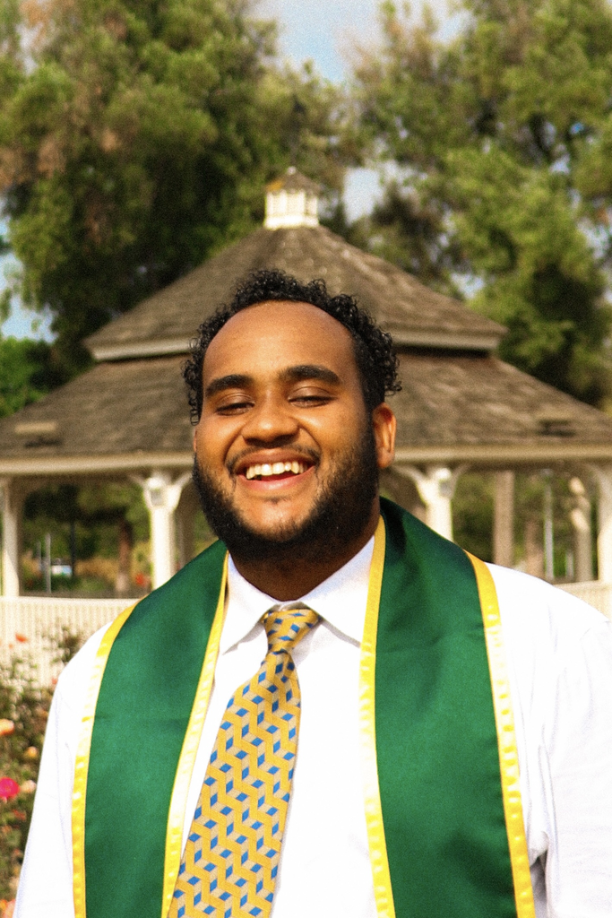

## About Me

I am a graduate student pursuing a Master of Science in Digital Marketing at California State Polytechnic University, Pomona, with a Bachelor of Science in Marketing Management.

My professional interests lie at the intersection of marketing strategy, data analytics, advertising technology, and consumer behavior. I leverage analytical tools and research methodologies to translate complex data into actionable marketing insights.

## Education

### California State Polytechnic University, Pomona

- **M.S. Digital Marketing** — In Progress
- **B.S. Marketing Management**

## Career Aspirations

My career objective is to pursue opportunities in marketing analytics, advertising operations, programmatic advertising, and marketing science.

My long-term goal is to contribute to marketing education as a university instructor, combining professional industry experience with academic research.

## Technical and Professional Skills

| Category | Skills |
| --- | --- |
| Data Analytics | R, SQL, Excel, BigQuery |
| Data Visualization | Tableau, Looker Studio, Quarto |
| Digital Analytics | Google Analytics 4, Google Search Console |
| Paid Media | Google Ads, Meta Ads, Programmatic Advertising |
| Advertising Operations | Campaign Measurement, CM360 Fundamentals |
| SEO | SEMrush, Keyword Research, Technical SEO |
| Marketing Research | Survey Design, Regression, Consumer Behavior |
| Development | HTML, CSS, SCSS, GitHub, RStudio |

## Professional Certifications

- Google Analytics 4 Certification
- Google Ads Display Certification
- SEMrush Keyword Research
- SEMrush Technical SEO
- Excel Pivot Tables

## Featured Work

**NoteMarketing Analytics and Research**

Explore my CEP Research Dashboard to learn about the application of marketing analytics to customer relationship management and technology adoption.

**NoteProfessional Portfolio**

Explore my Portfolio Projects to discover selected projects in digital marketing, analytics, and research.

**NoteWebsite Development**

Learn how this website was developed and customized using CSS and SCSS.